# Compound specific isotope analysis of individual amino acids in reef corals

CB Wall, NJ Wallsgrove, RD Gates, BN Popp (Limnology and Oceanography)

February 2021

```r
if (!require('knitr')) install.packages('knitr'); library('knitr')
knitr::opts_chunk$set(warning=FALSE, message=FALSE, fig.align='center')

###############
# Carbon and Nitrogen Isotopic Analysis of Individual Amino Acids in Montipora capitata
# Author: C. Wall
# Collaborators: Brian Popp, Ruth Gates, Natalie Wallsgrove
# Institution: University of Hawai'i at Mānoa
###############

# Load in packages
if (!require("pacman")) install.packages("pacman"); library(pacman) # for rapid install if not in library

pacman::p_load(devtools, ellipse, ggbiplot, vqv, patchwork, graphics, plyr, effects, MASS, tidyverse, dplyr, plotrix, vegan, cowplot, caret, reshape, car, emmeans, lmerTest)
```

### Background

Compound specific isotope analysis (CSIA) of individual amino acids (AA) have been developed to better understand ecosystem food webs, trophic positions, and sources of nutrition in biological samples ranging from bacteria to cetaceans. Bulk tissue isotope analysis requires separate accounting for isotopic signatures at the base of the food web, which vary in across locations and time periods. However, CSIA can account for both source and trophic isotope effects in a single sample of a consumer’s tissue. In reef coral, advances in AA-CSIA/isotope analysis and so called “isotope fingerprinting” may help advance the study of coral trophic plasticity.

Here, we exposed a reef coral (*Montipora capitata*) in symbiosis with Symbiodiniaceae algae to experimental treatments (autotrophy, mixotrophy, heterotrophy) to test for trophic shifts and amino acid (AA) sources using paired bulk (δ<sup>13</sup>C, δ<sup>15</sup>N) and AA-CSIA (δ<sup>13</sup>CAA, δ<sup>15</sup>NAA).

**AA grouping**  
*Esstential amino acids* (EAA) refer to AA-carbon, these are a group of amino acids that organisms require through their diet and show limited change across trophic levels.

*Non-essential amino acids* (NEAA) refer to AA-carbon, there amino acids are synthesized from carbon pools or direct routing of nonessential amino acids sourced from dietary protein.

*Source amino acids* refer to AA-nitrogen, with a group of AA that exhibit little change in isotopic composition with increasing trophic levels and reflect the isotopic composition of the ‘source material’ at the base of the food web from which they originated.

*Trophic amino acids* refer to AA-nitrogen, and are a group of AA that show significant <sup>15</sup>N enrichment compared to source-AA, which correspond to trophic steps.This enrichment is quite large and may exceed 8 ‰.

### Bulk isotopes

Bulk sample isotope data from plankton in Kāne’ohe Bay (previously published, Wall et al. 2020, *ISME J*)  
(1) **Plankton δ<sup>13</sup>C**

```r
SWiso<-read.csv("data/other/Wall_bulk_isotopes_SW_ismej.csv")

# fraction matters most
#### d13C
mod1<-(lm(d13C~Location+Season+SW.fraction..um, data=SWiso)); Anova(mod1, type=2) # no location or season effect
```

```
## Anova Table (Type II tests)
##
## Response: d13C
##                  Sum Sq Df F value    Pr(>F)
## Location         17.926  5  1.3418 0.2626013
## Season            7.921  1  2.9645 0.0914188 .
## SW.fraction..um  76.419  4  7.1504 0.0001286 ***
## Residuals       130.920 49
## ---
## Signif. codes:  0 '***' 0.001 '**' 0.01 '*' 0.05 '.' 0.1 ' ' 1
```

```r
posthoc<-emmeans(mod1, ~SW.fraction..um)
multcomp::cld(posthoc, Letters=letters) # only diff for the 10-100 um fraction
```

```
##  SW.fraction..um emmean    SE df lower.CL upper.CL .group
##  100-243          -21.1 0.472 49    -22.0    -20.1  a
##  0-10             -21.0 0.472 49    -22.0    -20.1  a
##  >243             -20.8 0.472 49    -21.7    -19.8  a
##  <243             -20.4 0.472 49    -21.4    -19.5  a
##  10-100           -18.1 0.472 49    -19.0    -17.1   b
##
## Results are averaged over the levels of: Location, Season
## Confidence level used: 0.95
## P value adjustment: tukey method for comparing a family of 5 estimates
## significance level used: alpha = 0.05
```

2. **Plankton δ<sup>15</sup>N**

```r
#### d15N
mod2<-(lm(d15N~Location+Season+SW.fraction..um, data=SWiso)); Anova(mod2, type=2) # mild season effect
```

```
## Anova Table (Type II tests)
##
## Response: d15N
##                  Sum Sq Df F value    Pr(>F)
## Location         2.3255  5  1.7291   0.14557
## Season           1.0935  1  4.0653   0.04927 *
## SW.fraction..um 30.3773  4 28.2335 3.454e-12 ***
## Residuals       13.1802 49
## ---
## Signif. codes:  0 '***' 0.001 '**' 0.01 '*' 0.05 '.' 0.1 ' ' 1
```

```r
posthoc<-emmeans(mod2, ~SW.fraction..um)
multcomp::cld(posthoc, Letters=letters)
```

```
##  SW.fraction..um emmean   SE df lower.CL upper.CL .group
##  0-10              5.33 0.15 49     5.03     5.63  a
##  <243              5.92 0.15 49     5.62     6.22  ab
##  100-243           6.50 0.15 49     6.20     6.80   bc
##  >243              6.77 0.15 49     6.47     7.07    c
##  10-100            7.41 0.15 49     7.11     7.71     d
##
## Results are averaged over the levels of: Location, Season
## Confidence level used: 0.95
## P value adjustment: tukey method for comparing a family of 5 estimates
## significance level used: alpha = 0.05
```

```r
posthoc<-emmeans(mod2, ~Season)
multcomp::cld(posthoc, Letters=letters) # diff small <0.3 permil
```

```
##  Season emmean     SE df lower.CL upper.CL .group
##  summer   6.25 0.0947 49     6.06     6.44  a
##  winter   6.52 0.0947 49     6.33     6.71   b
##
## Results are averaged over the levels of: Location, SW.fraction..um
## Confidence level used: 0.95
## significance level used: alpha = 0.05
```

```r
########
SWiso$Reef<-factor(SWiso$Reef, levels=c("F1-46", "R42", "F2-R25", "R25", "F8-R10", "HIMB"))
SWiso$Location<-factor(SWiso$Location, levels=c("NW", "NE", "CW", "CE", "SW", "SE"))
SWiso$SW.fraction..um<-factor(SWiso$SW.fraction..um, levels=c(">243", "<243", "100-243", "10-100", "0-10"))

winter.data<-SWiso[(SWiso$Season=="winter"),]
summer.data<-SWiso[(SWiso$Season=="summer"),]

#### making scatter for d15N and d13C, pooled across seasons and sites
mix.N.mean<-aggregate(d15N~SW.fraction..um, data=SWiso, mean)
mix.N.se<-aggregate(d15N~SW.fraction..um, data=SWiso, std.error)
mix.N.n<-aggregate(d15N~SW.fraction..um, data=SWiso, length)

mix.C.mean<-aggregate(d13C~SW.fraction..um, data=SWiso, mean)
mix.C.se<-aggregate(d13C~SW.fraction..um, data=SWiso, std.error)
mix.C.n<-aggregate(d13C~SW.fraction..um, data=SWiso, length)

mix.data<-cbind(mix.N.mean, mix.C.mean[c(2,0)], mix.N.se[c(2,0)], mix.C.se[c(2,0)]); colnames(mix.data)=c("fraction", "d15N", "d13C", "d15N.se", "d13C.se")

write.table(mix.data, file = "output/bulk isotopes.Wall.ISMEJ.csv", sep = ",", quote = FALSE, row.names = F)
```

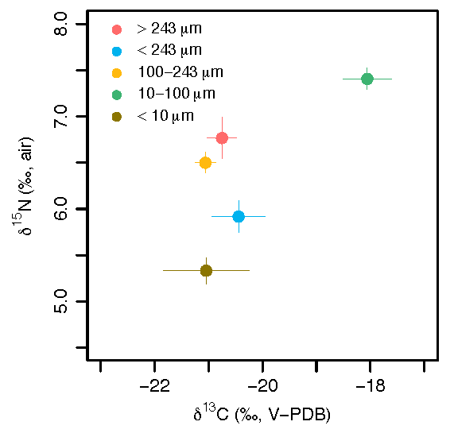

**Figure NA.** *Stable isotope C and N in plankton samples by size fraction from summer and winter 2016 at six sampling locations.*

Carbon and nitrogen isotope values in plankton, Symbiodiniaceae symbionts and coral host tissues. With linear models testing effect of treatment and fraction

```r
bulk<-read.csv("data/bulkCN.isotopes.csv")
bulk$Treat.Int<-factor(bulk$Treat.Int, levels=c("L-NF", "L-F", "D-F", "plank"))
bulk$Fraction<-factor(bulk$Fraction, levels=c("host", "symb", "plank"))

bulk.HS<-bulk[!(bulk$Fraction=="plank"),] # plankton removed from fraction

bulk.d15N.means<-aggregate(d15N~Fraction+Treat.Int, data=bulk, mean, na.rm=TRUE)
bulk.d13C.means<-aggregate(d13C~Fraction+Treat.Int, data=bulk, mean, na.rm=TRUE)
bulk.CN.means<-aggregate(C.N~Fraction+Treat.Int, data=bulk, mean, na.rm=TRUE)

bulk.means<-cbind(bulk.d15N.means, bulk.d13C.means[3], bulk.CN.means[3])


### fig formatting
format.fig<-
  theme(axis.ticks.length=unit(0.25, "cm"),
        axis.text.y=element_text(margin=unit(c(0.5, 0.5, 0.5, 0.5), "cm")),
        axis.text.x=element_text(margin=unit(c(0.5, 0.5, 0.5, 0.5), "cm"))) +
  theme(text = element_text(size=8)) +
  theme(legend.text=element_text(size=10), legend.key = element_blank()) +
  theme(panel.grid.major = element_blank(),
      panel.grid.minor = element_blank(),
      panel.background = element_blank(),
      axis.line = element_line(colour = "black",  size=0.5))


##### bulk figures
d13C.m<-aggregate(d13C~Treat.Int, data=bulk, mean, na.rm=TRUE)
d13C.n<-aggregate(d13C~Treat.Int, data=bulk, length)

# d13C
d13C.plot<-ggplot(bulk, aes(y=d13C, x=Treat.Int))+
  geom_boxplot(aes(fill=Fraction)) +
  geom_dotplot(aes(fill = Fraction, color = Fraction),
               binaxis='y', stackdir='center', dotsize = 0.5, alpha=0.5,
               position = position_dodge(0.75))+
  ylab(expression(paste(delta^{13}, C, " (\u2030, V-PDB)")))+
  xlab("Treatment") + theme(legend.title = element_blank()) +
  format.fig
```

1. **Bulk δ<sup>13</sup>C: Fraction and Treatment**

```r
anova(lm(d13C ~ Fraction+Treat.Int, data=bulk.HS))
```

```
## Analysis of Variance Table
##
## Response: d13C
##           Df Sum Sq Mean Sq F value Pr(>F)
## Fraction   1 1.4008 1.40083  1.5317 0.2510
## Treat.Int  2 3.7717 1.88583  2.0620 0.1896
## Residuals  8 7.3167 0.91458
```

2. **Bulk δ<sup>15</sup>N: Fraction and Treatment**

```r
# d15N
d15N.plot<-ggplot(bulk, aes(y=d15N, x=Treat.Int))+
  geom_boxplot(aes(fill=Fraction)) +
  geom_dotplot(aes(fill = Fraction, color = Fraction),
               binaxis='y', stackdir='center', dotsize = 0.5, alpha=0.5,
               position = position_dodge(0.75))+
  ylab(expression(paste(delta^{15}, N, " (\u2030, air)")))+
  xlab("Treatment") +
  format.fig + theme(legend.position = "none")

anova(lm(d15N ~ Fraction+Treat.Int, data=bulk.HS))
```

```
## Analysis of Variance Table
##
## Response: d15N
##           Df Sum Sq Mean Sq F value   Pr(>F)
## Fraction   1 4.0833  4.0833 14.7702 0.004925 **
## Treat.Int  2 0.1050  0.0525  0.1899 0.830662
## Residuals  8 2.2117  0.2765
## ---
## Signif. codes:  0 '***' 0.001 '**' 0.01 '*' 0.05 '.' 0.1 ' ' 1
```

3. **Bulk coral-symbiont C:N: Fraction and Treatment**

```r
####
# C:N
C.N.plot<-ggplot(bulk, aes(y=C.N, x=Treat.Int), na.rm=T)+
  geom_boxplot(aes(fill=Fraction)) +
  geom_dotplot(aes(fill = Fraction, color = Fraction),
               binaxis='y', stackdir='center', dotsize = 0.5, alpha=0.5,
               position = position_dodge(0.75))+
  ylab(expression(paste(C:N)))+
  xlab("Treatment") +
  format.fig + theme(legend.position = "none")

anova(lm(C.N ~ Fraction+Treat.Int, data=bulk.HS))
```

```
## Analysis of Variance Table
##
## Response: C.N
##           Df  Sum Sq Mean Sq F value  Pr(>F)
## Fraction   1 0.13168 0.13168  0.7228 0.41995
## Treat.Int  2 2.21760 1.10880  6.0861 0.02474 *
## Residuals  8 1.45749 0.18219
## ---
## Signif. codes:  0 '***' 0.001 '**' 0.01 '*' 0.05 '.' 0.1 ' ' 1
```

4. **Bulk difference in coral-symbiont δ<sup>13</sup>C: Treatment**

```r
####
# d13H-S
d13C.HS.plot<-ggplot(bulk.HS, aes(y=d13C.H.S, x=Treat.Int), na.rm=T)+
  geom_boxplot(fill=c("lightblue", "goldenrod1", "gray50")) +
  geom_dotplot(fill=c("lightblue", "lightblue", "darkgoldenrod1",  "darkgoldenrod1", "gray50", "gray50"),
               binaxis='y', stackdir='center', dotsize = 0.5, alpha=0.5,
               position = position_dodge(0.75))+
  ylab(expression(paste(delta^{13}, C[H-S], " (\u2030)"))) +
  xlab("Treatment") +
  format.fig + theme(legend.position = "none")

anova(lm(d13C.H.S ~ Treat.Int, data=bulk.HS))
```

```
## Analysis of Variance Table
##
## Response: d13C.H.S
##           Df  Sum Sq Mean Sq F value  Pr(>F)
## Treat.Int  2 0.76333 0.38167  7.8966 0.06378 .
## Residuals  3 0.14500 0.04833
## ---
## Signif. codes:  0 '***' 0.001 '**' 0.01 '*' 0.05 '.' 0.1 ' ' 1
```

5. **Bulk differences in coral-symbiont δ<sup>15</sup>N: Treatment**

```r
# d15NH-S
d15N.HS.plot<-ggplot(bulk.HS, aes(y=d15N.H.S, x=Treat.Int), na.rm=T)+
  geom_boxplot(fill=c("lightblue", "darkgoldenrod1", "gray50")) +
  geom_dotplot(fill=c("lightblue", "lightblue", "darkgoldenrod1",  "darkgoldenrod1", "gray50", "gray50"),
               binaxis='y', stackdir='center', dotsize = 0.5, alpha=0.5,
               position = position_dodge(0.75))+
  ylab(expression(paste(delta^{15}, N[H-S], " (\u2030)")))+
  xlab("Treatment") +
  format.fig + theme(legend.position = "none")

anova(lm(d15N.H.S ~ Treat.Int, data=bulk.HS))
```

```
## Analysis of Variance Table
##
## Response: d15N.H.S
##           Df  Sum Sq  Mean Sq F value Pr(>F)
## Treat.Int  2 0.06333 0.031667  0.2879 0.7685
## Residuals  3 0.33000 0.110000
```

6. **Bulk tissue isotope coral-symbiont figure**

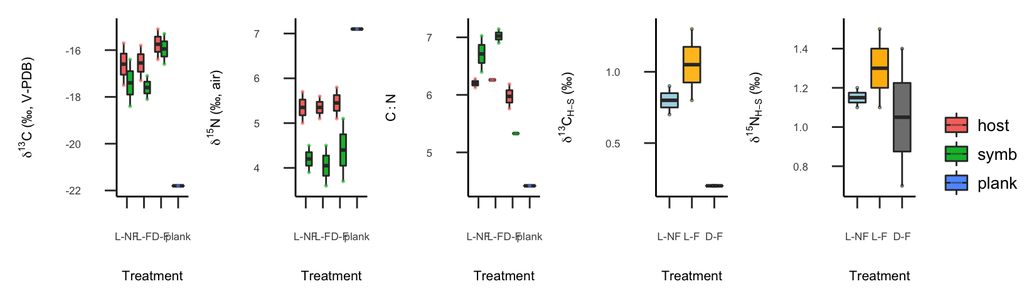

```r
####

bulk.legend <- get_legend(
  # create some space to the left of the legend
  d13C.plot + theme(legend.box.margin = margin(0, 0, 0, 12)))

bulk.figures<-(d13C.plot+theme(legend.position = "none") | d15N.plot | C.N.plot | d13C.HS.plot | d15N.HS.plot |
                 bulk.legend)
print(bulk.figures)
```

```r
ggsave("figures/execute code/Fig 1. bulk isotope.pdf", height=3.5, width=12, encod="MacRoman")
```

### CSIA Carbon and Nitrogen

Carbon in amino acids of plankton, Symbiodiniaceae symbionts and coral host tissues.

```r
######## ########
## Carbon
######## ########
rm(list=ls())
d13C.dat<-read.csv("data/d13C.CSIA.wide.csv") # wide form carbon data

colnames(d13C.dat)
d13C.dat$Fraction<-factor(d13C.dat$Fraction, levels=c("host", "symb", "plank"))
d13C.dat$Treat.Int<-factor(d13C.dat$Treat.Int, levels=c("L-NF", "L-F", "D-F", "plank"))
d13C.dat<-d13C.dat[ , !(names(d13C.dat) %in% c("Norleucine", "Aminoadipic.Acid", "Methionine"))] #remove Norleucine, Methionine, Aminoadipic Acid


######## ########
## Nitrogen
######## ########
d15N.dat<-read.csv("data/d15N.CSIA.wide.csv") # wide form carbon data
d15N.dat<-d15N.dat[ , !(names(d15N.dat) %in% c("Norleucine", "Aminoadipic.Acid", "Methionine"))]
d15N.dat$Fraction<-factor(d15N.dat$Fraction, levels=c("host", "symb", "plank"))
```

#### Permanova

Carbon isotope PERMANOVA using levels of Fraction and Treatment

```r
## Permanova carbon
d13C.dat.perm<- d13C.dat[!(d13C.dat$Fraction=="plank"),]
df.manova.C<-d13C.dat.perm[, c(11:23)] # remove factor columns
df.manova.C.abs<-abs(df.manova.C) # change all to absolute values

set.seed(138)
perman.C<-adonis2(df.manova.C.abs~Fraction*Treat.Int, data=d13C.dat.perm, permutations=1000,
                method="euclidean", sqrt.dist = TRUE)
perman.C
```

```
## Permutation test for adonis under reduced model
## Terms added sequentially (first to last)
## Permutation: free
## Number of permutations: 1000
##
## adonis2(formula = df.manova.C.abs ~ Fraction * Treat.Int, data = d13C.dat.perm, permutations = 1000, method = "euclidean", sqrt.dist = TRUE)
##                    Df SumOfSqs      R2      F  Pr(>F)
## Fraction            1    6.931 0.15293 1.7236 0.07493 .
## Treat.Int           2    7.895 0.17420 0.9817 0.46853
## Fraction:Treat.Int  2    6.369 0.14052 0.7919 0.74525
## Residual            6   24.128 0.53235
## Total              11   45.323 1.00000
## ---
## Signif. codes:  0 '***' 0.001 '**' 0.01 '*' 0.05 '.' 0.1 ' ' 1
```

```r
write.csv(perman.C, "output/perman.C.csv")
```

Nitrogen isotope PERMANOVA using levels of Fraction and Treatment

```r
## Permanova nitrogen
d15N.dat.perm<- d15N.dat[!(d15N.dat$Fraction=="plank"),]
d15N.dat.perm$Threonine<-d15N.dat.perm$Threonine+3 # adding a constant to make positive values
d15N.dat.perm$Phenylalanine<-d15N.dat.perm$Phenylalanine+3 # adding a constant to make positive values

df.manova.N<-d15N.dat.perm[, c(11:23)] # remove factor columns

set.seed(138)
perman.N<-adonis2(df.manova.N~Fraction*Treat.Int, data=d15N.dat.perm, permutations=1000,
                method="euclidean", sqrt.dist = TRUE)
perman.N
```

```
## Permutation test for adonis under reduced model
## Terms added sequentially (first to last)
## Permutation: free
## Number of permutations: 1000
##
## adonis2(formula = df.manova.N ~ Fraction * Treat.Int, data = d15N.dat.perm, permutations = 1000, method = "euclidean", sqrt.dist = TRUE)
##                    Df SumOfSqs      R2      F  Pr(>F)
## Fraction            1    7.065 0.18165 2.0418 0.01499 *
## Treat.Int           2    4.753 0.12220 0.6868 0.92408
## Fraction:Treat.Int  2    6.315 0.16235 0.9124 0.60140
## Residual            6   20.763 0.53380
## Total              11   38.896 1.00000
## ---
## Signif. codes:  0 '***' 0.001 '**' 0.01 '*' 0.05 '.' 0.1 ' ' 1
```

```r
write.csv(perman.N, "output/perman.N.csv")
```

#### PCA

Four PCAs  
(a) *Carbon PCA by fraction (plankton, host, symbiont)*  
(b) *Nitrogen PCA by fraction (plankton, host, symbiont)*  
(c) *Carbon PCA by treatment*  
(d) *Nitrogen PCA by treatment*

```r
######## ######## ######## ######## carbon by fraction
# PCA dataframe
PCA.df.C<-d13C.dat[, c(7:8,11:23)]

PC.C<- prcomp(PCA.df.C[,c(-1:-2)], center = TRUE, scale= TRUE)
PC.C.summary<-summary(PC.C)
ev.C<-PC.C$sdev^2
newdat.C<-PC.C$x[,1:4] # 2 PCAs explain 81% of variance
#plot(PC, type="lines", main="PC.area eigenvalues")

frac.color<- c("coral", "seagreen3", "mediumorchid")

PC.fig3.C.frac <- ggbiplot(PC.C, choices = 1:2, obs.scale = 1, var.scale = 1,
                   groups= PCA.df.C[,2], ellipse = TRUE, ellipse.prob=0.90,
                   circle = FALSE) +
  scale_color_manual(values=frac.color)+
  theme_classic() +
  coord_cartesian(xlim = c(-8, 8), ylim=c(-4, 4)) +
  theme(axis.ticks.length=unit(-0.25, "cm"), axis.text.y=element_text(margin=unit(c(0.5, 0.5, 0.5, 0.5), "cm")), axis.text.x=element_text(margin=unit(c(0.5, 0.5, 0.5, 0.5), "cm"))) +
  theme(legend.text=element_text(size=10)) +
  theme(panel.background = element_rect(colour = "black", size=1))+
  theme(legend.key = element_blank())+
  theme(legend.direction = 'horizontal', legend.position = 'top') +theme(aspect.ratio=0.8) +
  annotate("text", x=6, y=3.6,  size=5, label= expression(paste(delta^{13},C[AA])))
print(PC.fig3.C.frac)
```

```r
#ggsave("figures/execute code/carbon/PCA_d13C.frac.pdf", height=5, width=8, encod="MacRoman")
```

```r
# PCA dataframe
PCA.df.N<-d15N.dat[, c(7:8,11:23)]

PC.N<- prcomp(PCA.df.N[, c(-1:-2)], center = TRUE, scale= TRUE)
PC.N.summary<-summary(PC.N)
ev.N<-PC.N$sdev^2
newdat.N<-PC.N$x[,1:4] # 2 PCAs explain 74% of variance
#plot(PC, type="lines", main="PC.area eigenvalues")

######################### nitrogen by fractions
## PC1 and PC2
PC.fig4.N.frac <- ggbiplot(PC.N, choices = 1:2, obs.scale = 1, var.scale = 1,
                   groups= PCA.df.N[,2], ellipse = TRUE, ellipse.prob=0.90,
                   circle = FALSE) +
  scale_color_manual(values=frac.color)+
  theme_classic() +
  coord_cartesian(xlim = c(-8, 5), ylim=c(-6, 6)) +
  theme(axis.ticks.length=unit(-0.25, "cm"), axis.text.y=element_text(margin=unit(c(0.5, 0.5, 0.5, 0.5), "cm")), axis.text.x=element_text(margin=unit(c(0.5, 0.5, 0.5, 0.5), "cm"))) +
  theme(legend.text=element_text(size=10)) +
  theme(panel.background = element_rect(colour = "black", size=1))+
  theme(legend.key = element_blank())+
  theme(legend.direction = 'horizontal', legend.position = 'top') +theme(aspect.ratio=0.8) +
  annotate("text", x=4, y=5.5,  size=5, label= expression(paste(delta^{15},N[AA])))
print(PC.fig4.N.frac)
```

```r
#ggsave("figures/execute code/nitrogen/PCA_d15N.frac.pdf", height=5, width=8, encod="MacRoman")
```

```r
######## ######## ######## ######## carbon by treatment
# PCA dataframe
PCA.df.C$Treat.Int<-factor(PCA.df.C$Treat.Int,
                              levels=c("L-NF", "L-F", "D-F", "plank"))

## PC1 and PC2
trt.color<-c("lightskyblue", "darkgoldenrod1", "gray70", "mediumorchid")

PC.fig1.C.trt <- ggbiplot(PC.C, choices = 1:2, obs.scale = 1, var.scale = 1,
                             groups= PCA.df.C[,1], ellipse = TRUE, ellipse.prob=0.90,
                             circle = FALSE) +
  scale_color_manual(values=trt.color)+
  theme_classic() +
  scale_x_continuous(breaks=pretty_breaks(n=5))+
  coord_cartesian(xlim = c(-8, 8), ylim=c(-4, 4))+
  theme(axis.ticks.length=unit(-0.25, "cm"), axis.text.y=element_text(margin=unit(c(0.5, 0.5, 0.5, 0.5), "cm")), axis.text.x=element_text(margin=unit(c(0.5, 0.5, 0.5, 0.5), "cm"))) +
  theme(legend.text=element_text(size=10)) +
  theme(panel.background = element_rect(colour = "black", size=1))+
  theme(legend.key = element_blank())+
  theme(legend.direction = 'horizontal', legend.position = 'top') +theme(aspect.ratio=0.8) +
  annotate("text", x=6, y=3.6,  size=5, label= expression(paste(delta^{13},C[AA])))
print(PC.fig1.C.trt)
```

```r
#ggsave("figures/execute code/carbon/PCA_d13C.trt.pdf", height=5, width=8, encod="MacRoman")
```

```r
######################## nitrogen by treatments
PCA.df.N$Treat.Int<-factor(PCA.df.N$Treat.Int,
                              levels=c("L-NF", "L-F", "D-F", "plank"))

trt.color<-c("lightskyblue", "darkgoldenrod1", "gray70", "mediumorchid")

## PC1 and PC2
PC.fig2.N.trt <- ggbiplot(PC.N, choices = 1:2, obs.scale = 1, var.scale = 1,
                   groups= PCA.df.N[,1], ellipse = TRUE, ellipse.prob=0.90,
                   circle = FALSE) +
  scale_color_manual(values=trt.color)+
  theme_classic() +
  coord_cartesian(xlim = c(-8, 5), ylim=c(-6, 6)) +
  theme(axis.ticks.length=unit(-0.25, "cm"), axis.text.y=element_text(margin=unit(c(0.5, 0.5, 0.5, 0.5), "cm")), axis.text.x=element_text(margin=unit(c(0.5, 0.5, 0.5, 0.5), "cm"))) +
  theme(legend.text=element_text(size=10)) +
  theme(panel.background = element_rect(colour = "black", size=1))+
  theme(legend.key = element_blank())+
  theme(legend.direction = 'horizontal', legend.position = 'top') +theme(aspect.ratio=0.8) +
  annotate("text", x=4, y=5.5,  size=5, label= expression(paste(delta^{15},N[AA])))
print(PC.fig2.N.trt)
```

```r
#ggsave("figures/execute code/nitrogen/PCA_d15N.trt.pdf", height=5, width=6, encod="MacRoman")
```

**Figure 2– 4 panel PCA.combined**

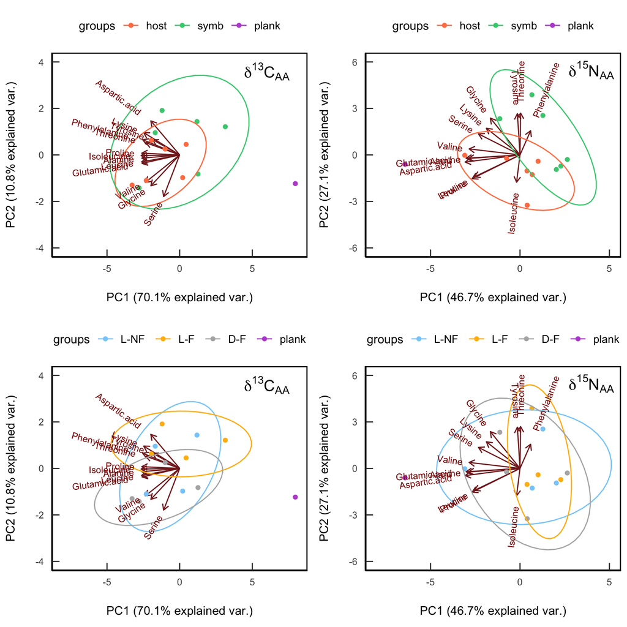

*Figure 2*. Principal component analysis of carbon (left) and nitrogen (right) isotope values of individual amino acids in corals, Symbiodiniaceae, and a pooled plankton sample in relation to tissue fraction (top) and treatments (bottom). Ellipses represent 90% standard deviation with arrows for individual amino acids being significant (p<0.05) correlation vectors.

```r
#### compile the 4 PCA ###
library("cowplot")
plot_grid(PC.fig3.C.frac, PC.fig4.N.frac, PC.fig1.C.trt, PC.fig2.N.trt, ncol = 2)
```

```r
ggsave("figures/execute code/Fig 2.PCAs.pdf", height=8, width=11, encod="MacRoman")

######
```

### Carbon AA

#### Models

Run models looking for effects of Fraction or the Treatment-Interaction (feeding/light).

```
## Analysis of Variance Table
##
## Response: Y
##           Df  Sum Sq Mean Sq F value  Pr(>F)
## Fraction   1  7.9280  7.9280  4.8489 0.05881 .
## Treat.Int  2  2.3861  1.1931  0.7297 0.51157
## Residuals  8 13.0802  1.6350
## ---
## Signif. codes:  0 '***' 0.001 '**' 0.01 '*' 0.05 '.' 0.1 ' ' 1
##   Tukey multiple comparisons of means
##     95% family-wise confidence level
##
## Fit: aov(formula = Y ~ Fraction + Treat.Int, data = d13C.dat2)
##
## $Fraction
##                diff       lwr        upr     p adj
## symb-host -1.625629 -3.328026 0.07676902 0.0588088
##
## $Treat.Int
##                diff       lwr      upr     p adj
## L-F-L-NF -1.0214364 -3.605031 1.562158 0.5238902
## D-F-L-NF -0.1756140 -2.759208 2.407980 0.9794709
## D-F-L-F   0.8458224 -1.737772 3.429417 0.6346704
```

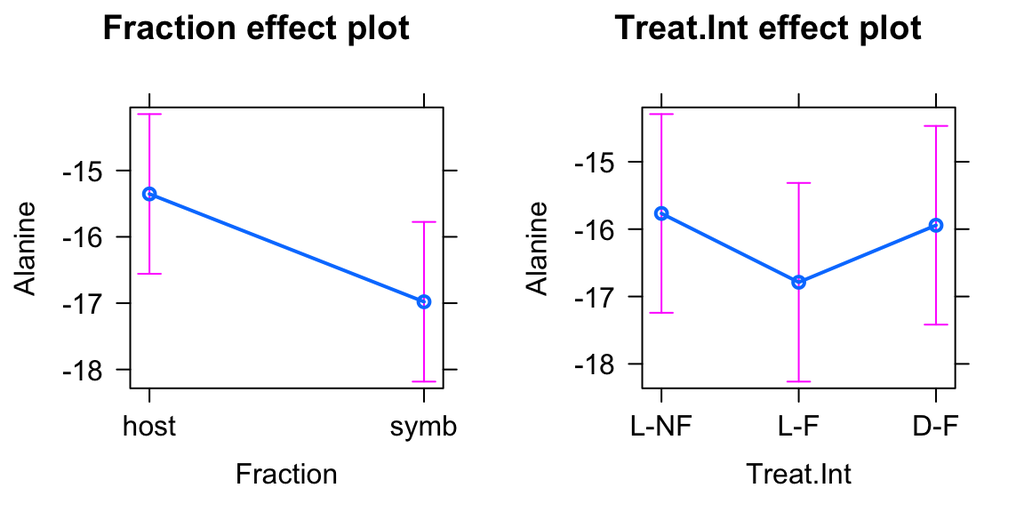

```
## Analysis of Variance Table
##
## Response: Y
##           Df Sum Sq Mean Sq F value   Pr(>F)
## Fraction   1 43.514  43.514  16.281 0.003762 **
## Treat.Int  2 38.910  19.455   7.279 0.015818 *
## Residuals  8 21.382   2.673
## ---
## Signif. codes:  0 '***' 0.001 '**' 0.01 '*' 0.05 '.' 0.1 ' ' 1
##   Tukey multiple comparisons of means
##     95% family-wise confidence level
##
## Fit: aov(formula = Y ~ Fraction + Treat.Int, data = d13C.dat2)
##
## $Fraction
##                diff       lwr       upr     p adj
## symb-host -3.808515 -5.985115 -1.631916 0.0037621
##
## $Treat.Int
##               diff       lwr       upr     p adj
## L-F-L-NF -2.323060 -5.626314 0.9801931 0.1719320
## D-F-L-NF  2.085575 -1.217679 5.3888282 0.2286943
## D-F-L-F   4.408635  1.105382 7.7118885 0.0126616
```

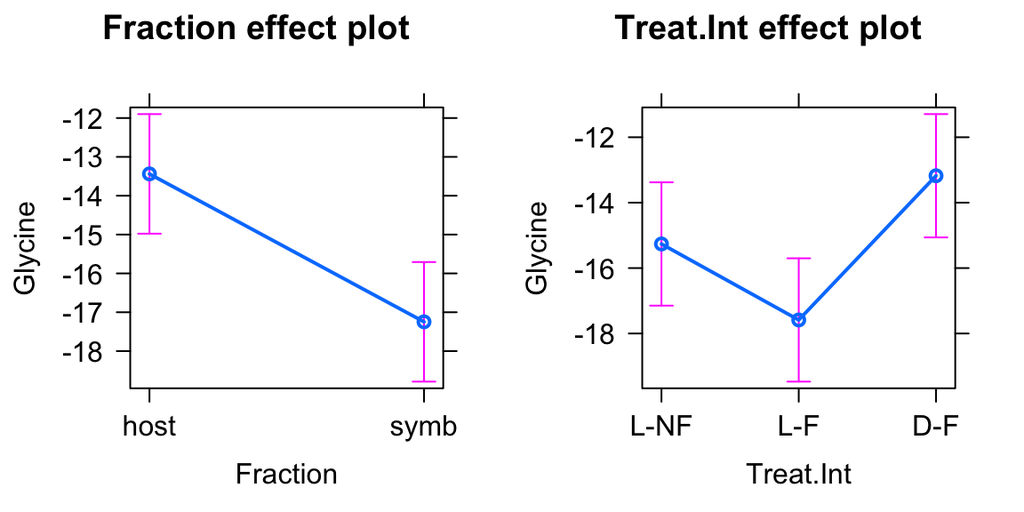

```
## Analysis of Variance Table
##
## Response: Y
##           Df Sum Sq Mean Sq F value Pr(>F)
## Fraction   1  2.197  2.1971  0.4464 0.5228
## Treat.Int  2  5.526  2.7628  0.5614 0.5914
## Residuals  8 39.372  4.9215
##   Tukey multiple comparisons of means
##     95% family-wise confidence level
##
## Fit: aov(formula = Y ~ Fraction + Treat.Int, data = d13C.dat2)
##
## $Fraction
##                diff       lwr     upr     p adj
## symb-host 0.8557828 -2.097784 3.80935 0.5228408
##
## $Treat.Int
##                diff       lwr      upr     p adj
## L-F-L-NF -1.6618056 -6.144201 2.820590 0.5632924
## D-F-L-NF -0.8014268 -5.283822 3.680969 0.8682426
## D-F-L-F   0.8603788 -3.622017 5.342774 0.8501124
```

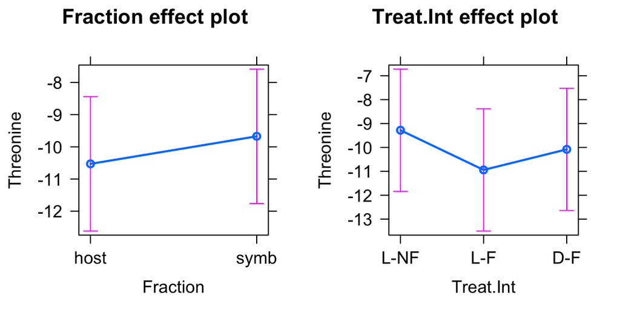

```
## Analysis of Variance Table
##
## Response: Y
##           Df  Sum Sq Mean Sq F value Pr(>F)
## Fraction   1  0.5098  0.5098  0.1910 0.6736
## Treat.Int  2 13.3334  6.6667  2.4977 0.1436
## Residuals  8 21.3529  2.6691
##   Tukey multiple comparisons of means
##     95% family-wise confidence level
##
## Fit: aov(formula = Y ~ Fraction + Treat.Int, data = d13C.dat2)
##
## $Fraction
##                diff       lwr     upr     p adj
## symb-host 0.4122222 -1.762895 2.58734 0.6736481
##
## $Treat.Int
##               diff        lwr      upr     p adj
## L-F-L-NF -1.363812 -4.6648158 1.937192 0.4961333
## D-F-L-NF  1.216790 -2.0842139 4.517794 0.5667464
## D-F-L-F   2.580602 -0.7204022 5.881606 0.1247308
```

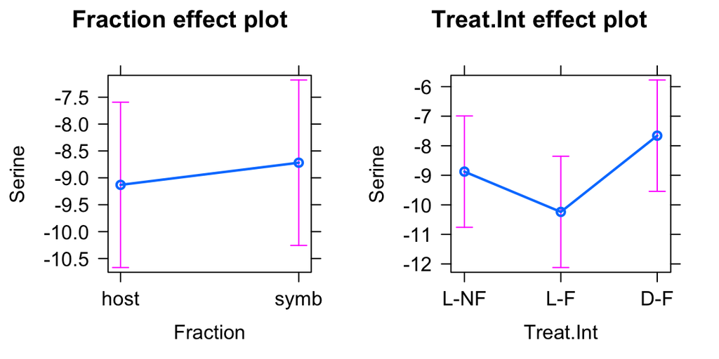

```
## Analysis of Variance Table
##
## Response: Y
##           Df  Sum Sq Mean Sq F value Pr(>F)
## Fraction   1  3.0549  3.0549  1.2730 0.2919
## Treat.Int  2  4.4772  2.2386  0.9328 0.4324
## Residuals  8 19.1986  2.3998
##   Tukey multiple comparisons of means
##     95% family-wise confidence level
##
## Fit: aov(formula = Y ~ Fraction + Treat.Int, data = d13C.dat2)
##
## $Fraction
##                diff       lwr      upr    p adj
## symb-host -1.009111 -3.071587 1.053365 0.291906
##
## $Treat.Int
##                diff       lwr      upr     p adj
## L-F-L-NF -0.5855417 -3.715598 2.544515 0.8569269
## D-F-L-NF  0.8996250 -2.230431 4.029681 0.7011505
## D-F-L-F   1.4851667 -1.644890 4.615223 0.4064527
```

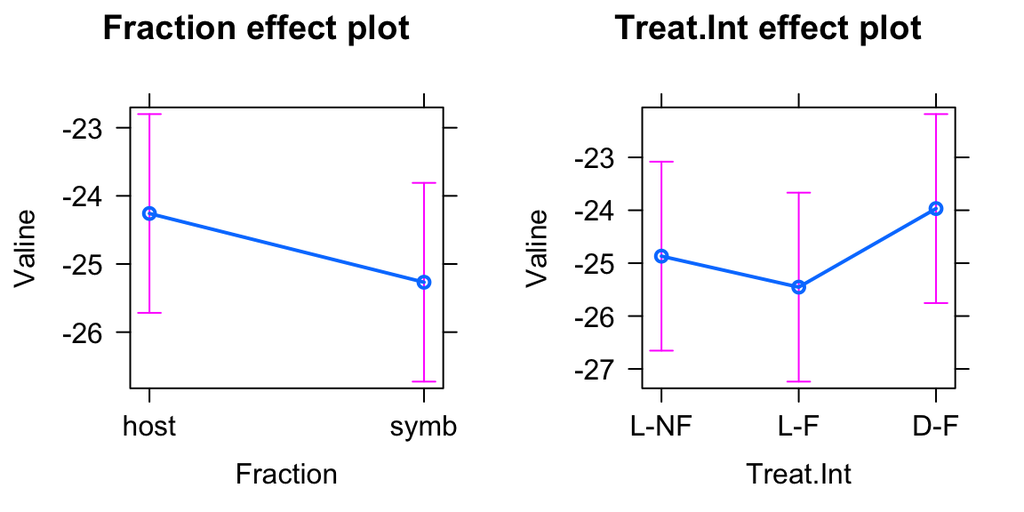

```
## Analysis of Variance Table
##
## Response: Y
##           Df Sum Sq Mean Sq F value Pr(>F)
## Fraction   1 0.1806 0.18060  0.1457 0.7126
## Treat.Int  2 1.8191 0.90953  0.7340 0.5097
## Residuals  8 9.9129 1.23912
##   Tukey multiple comparisons of means
##     95% family-wise confidence level
##
## Fit: aov(formula = Y ~ Fraction + Treat.Int, data = d13C.dat2)
##
## $Fraction
##                 diff       lwr      upr     p adj
## symb-host -0.2453535 -1.727379 1.236672 0.7125759
##
## $Treat.Int
##                diff       lwr      upr     p adj
## L-F-L-NF -0.5112879 -2.760441 1.737865 0.7978109
## D-F-L-NF  0.4415530 -1.807600 2.690706 0.8439105
## D-F-L-F   0.9528409 -1.296312 3.201994 0.4800982
```

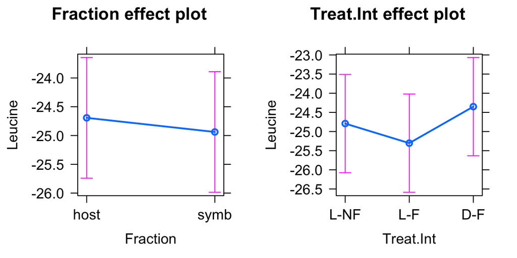

```
## Analysis of Variance Table
##
## Response: Y
##           Df Sum Sq Mean Sq F value Pr(>F)
## Fraction   1  2.301  2.3006  0.5090 0.4958
## Treat.Int  2  0.536  0.2681  0.0593 0.9428
## Residuals  8 36.157  4.5196
##   Tukey multiple comparisons of means
##     95% family-wise confidence level
##
## Fit: aov(formula = Y ~ Fraction + Treat.Int, data = d13C.dat2)
##
## $Fraction
##                 diff       lwr      upr     p adj
## symb-host -0.8757071 -3.706106 1.954692 0.4958429
##
## $Treat.Int
##                diff       lwr      upr     p adj
## L-F-L-NF -0.1529924 -4.448466 4.142481 0.9943098
## D-F-L-NF  0.3519318 -3.943541 4.647405 0.9703487
## D-F-L-F   0.5049242 -3.790549 4.800398 0.9401608
```

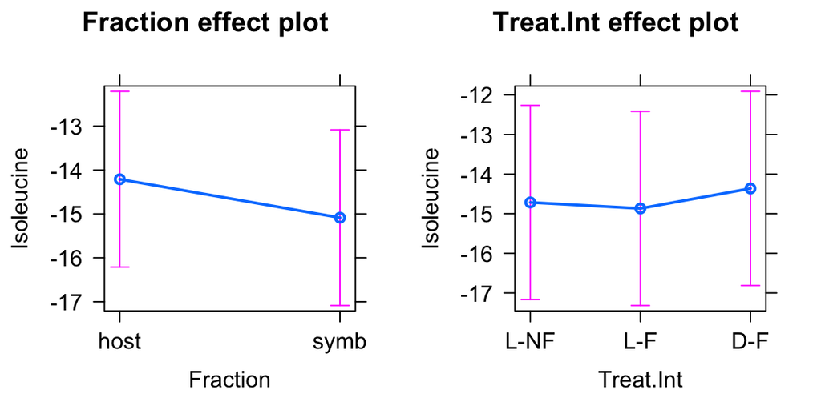

```
## Analysis of Variance Table
##
## Response: Y
##           Df  Sum Sq Mean Sq F value  Pr(>F)
## Fraction   1 10.0959 10.0959  5.0226 0.05533 .
## Treat.Int  2  1.9626  0.9813  0.4882 0.63089
## Residuals  8 16.0806  2.0101
## ---
## Signif. codes:  0 '***' 0.001 '**' 0.01 '*' 0.05 '.' 0.1 ' ' 1
##   Tukey multiple comparisons of means
##     95% family-wise confidence level
##
## Fit: aov(formula = Y ~ Fraction + Treat.Int, data = d13C.dat2)
##
## $Fraction
##                diff       lwr        upr     p adj
## symb-host -1.834472 -3.722052 0.05310792 0.0553284
##
## $Treat.Int
##                diff       lwr      upr     p adj
## L-F-L-NF -0.9262500 -3.790881 1.938381 0.6413964
## D-F-L-NF -0.1589583 -3.023590 2.705673 0.9862591
## D-F-L-F   0.7672917 -2.097340 3.631923 0.7333288
```

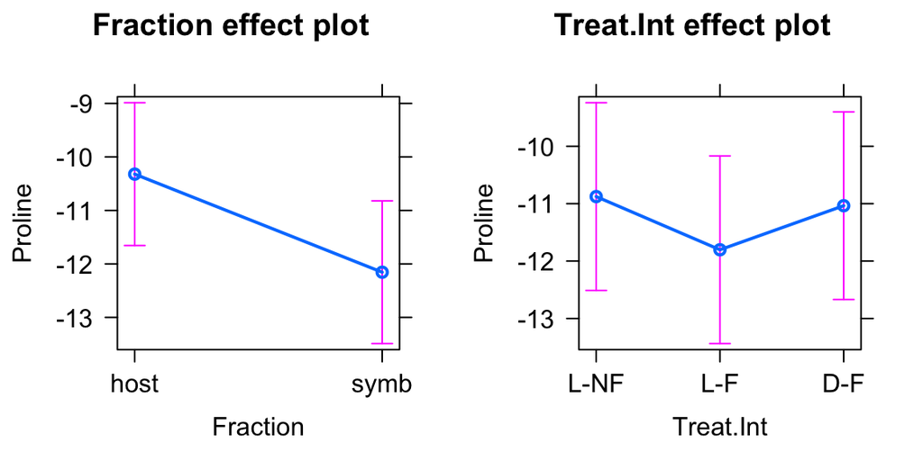

```
## Analysis of Variance Table
##
## Response: Y
##           Df  Sum Sq Mean Sq F value Pr(>F)
## Fraction   1  1.9366 1.93656  0.8704 0.3781
## Treat.Int  2  1.1095 0.55476  0.2494 0.7851
## Residuals  8 17.7984 2.22480
##   Tukey multiple comparisons of means
##     95% family-wise confidence level
##
## Fit: aov(formula = Y ~ Fraction + Treat.Int, data = d13C.dat2)
##
## $Fraction
##                diff       lwr      upr     p adj
## symb-host 0.8034428 -1.182399 2.789285 0.3781308
##
## $Treat.Int
##                diff       lwr      upr     p adj
## L-F-L-NF -0.3559343 -3.369690 2.657821 0.9396161
## D-F-L-NF -0.7445833 -3.758339 2.269172 0.7668729
## D-F-L-F  -0.3886490 -3.402404 2.625106 0.9285371
```

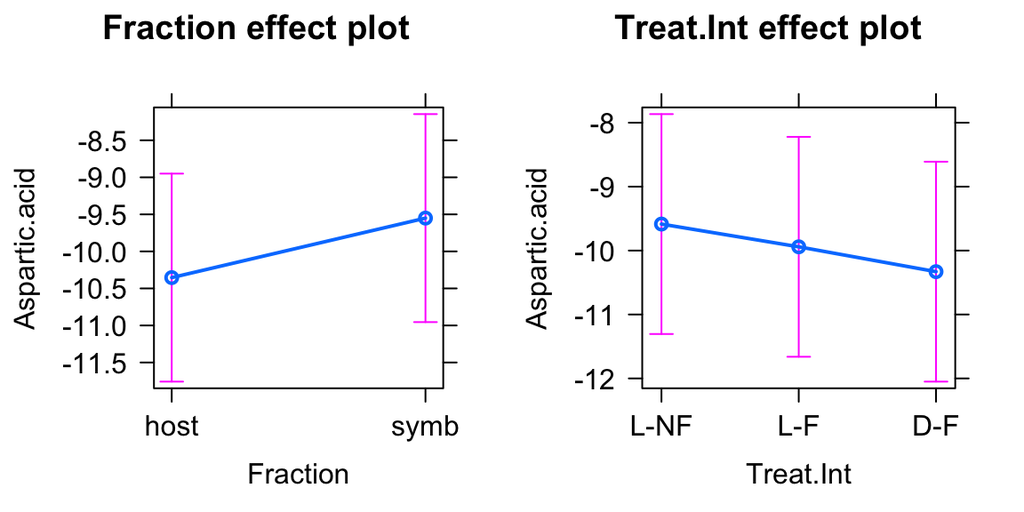

```
## Analysis of Variance Table
##
## Response: Y
##           Df  Sum Sq Mean Sq F value   Pr(>F)
## Fraction   1 15.4184 15.4184 15.5000 0.004314 **
## Treat.Int  2  7.1774  3.5887  3.6077 0.076423 .
## Residuals  8  7.9579  0.9947
## ---
## Signif. codes:  0 '***' 0.001 '**' 0.01 '*' 0.05 '.' 0.1 ' ' 1
##   Tukey multiple comparisons of means
##     95% family-wise confidence level
##
## Fit: aov(formula = Y ~ Fraction + Treat.Int, data = d13C.dat2)
##
## $Fraction
##                diff       lwr        upr     p adj
## symb-host -2.267039 -3.594905 -0.9391742 0.0043141
##
## $Treat.Int
##                diff        lwr      upr     p adj
## L-F-L-NF -0.3928728 -2.4080690 1.622323 0.8458544
## D-F-L-NF  1.4084868 -0.6067093 3.423683 0.1749601
## D-F-L-F   1.8013597 -0.2138365 3.816556 0.0781114
```

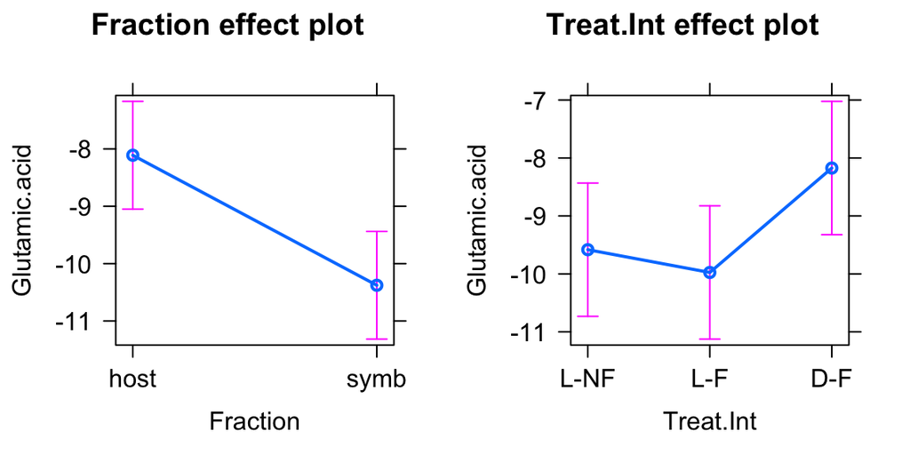

```
## Analysis of Variance Table
##
## Response: Y
##           Df  Sum Sq Mean Sq F value Pr(>F)
## Fraction   1  0.4717 0.47171  0.3402 0.5758
## Treat.Int  2  1.7167 0.85836  0.6190 0.5624
## Residuals  8 11.0933 1.38666
##   Tukey multiple comparisons of means
##     95% family-wise confidence level
##
## Fit: aov(formula = Y ~ Fraction + Treat.Int, data = d13C.dat2)
##
## $Fraction
##                 diff       lwr      upr     p adj
## symb-host -0.3965321 -1.964311 1.171246 0.5757947
##
## $Treat.Int
##                  diff       lwr      upr     p adj
## L-F-L-NF  0.805110680 -1.574183 3.184404 0.6164040
## D-F-L-NF  0.799570313 -1.579723 3.178864 0.6202649
## D-F-L-F  -0.005540367 -2.384834 2.373753 0.9999756
```

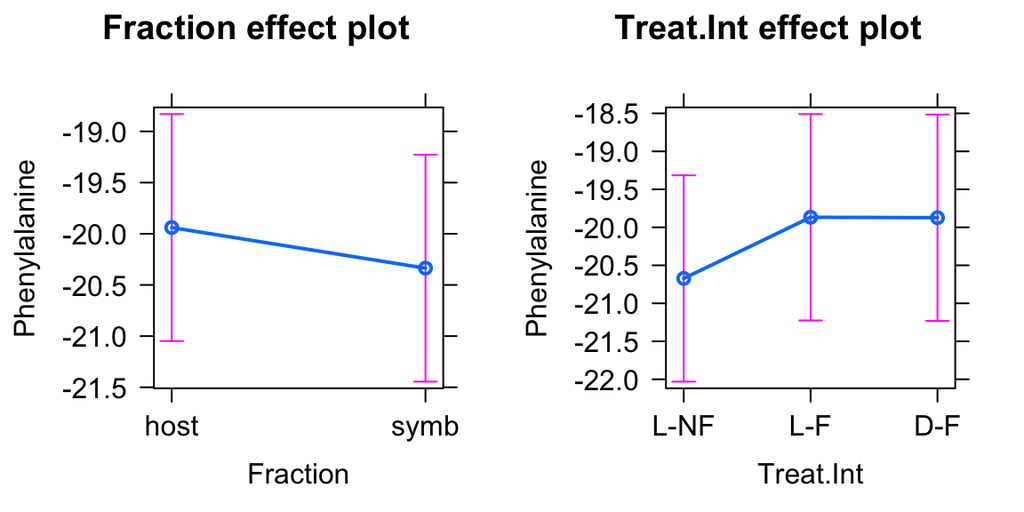

```
## Analysis of Variance Table
##
## Response: Y
##           Df  Sum Sq Mean Sq F value Pr(>F)
## Fraction   1  0.4274 0.42736  0.2195 0.6519
## Treat.Int  2  3.7940 1.89702  0.9743 0.4181
## Residuals  8 15.5772 1.94716
##   Tukey multiple comparisons of means
##     95% family-wise confidence level
##
## Fit: aov(formula = Y ~ Fraction + Treat.Int, data = d13C.dat2)
##
## $Fraction
##                diff       lwr      upr     p adj
## symb-host 0.3774306 -1.480373 2.235234 0.6519364
##
## $Treat.Int
##               diff       lwr      upr     p adj
## L-F-L-NF 1.1068359 -1.712606 3.926277 0.5282887
## D-F-L-NF 1.2633138 -1.556128 4.082755 0.4438334
## D-F-L-F  0.1564779 -2.662964 2.975919 0.9862544
```

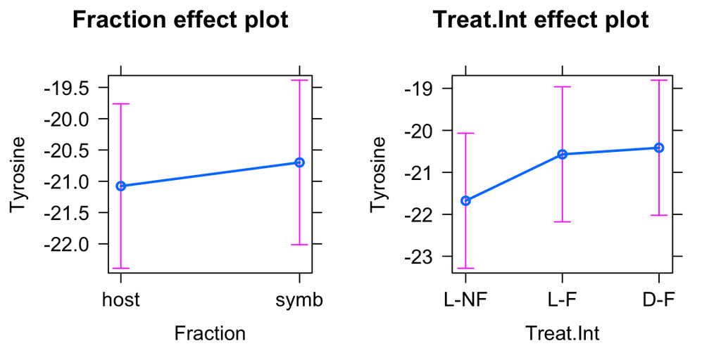

```
## Analysis of Variance Table
##
## Response: Y
##           Df  Sum Sq Mean Sq F value Pr(>F)
## Fraction   1  0.7150 0.71500  0.4577 0.5178
## Treat.Int  2  0.0828 0.04142  0.0265 0.9739
## Residuals  8 12.4980 1.56225
##   Tukey multiple comparisons of means
##     95% family-wise confidence level
##
## Fit: aov(formula = Y ~ Fraction + Treat.Int, data = d13C.dat2)
##
## $Fraction
##                 diff       lwr      upr     p adj
## symb-host -0.4881944 -2.152277 1.175888 0.5177911
##
## $Treat.Int
##                 diff       lwr      upr     p adj
## L-F-L-NF  0.14959239 -2.375854 2.675039 0.9843613
## D-F-L-NF -0.04470109 -2.570148 2.480746 0.9985909
## D-F-L-F  -0.19429348 -2.719740 2.331153 0.9737967
```

[1 more figures not shown]

```r
d13C.dat2<-d13C.dat[!(d13C.dat$Fraction=="plank"),] #remove plankton for now
d13C.host<-d13C.dat[(d13C.dat$Fraction=="host"),] # just host
d13C.symb<-d13C.dat[(d13C.dat$Fraction=="symb"),] # just symbiont

for(i in c(11:23)){
  Y=d13C.dat2[,i]
  mod<-aov(Y~Fraction+Treat.Int, data=d13C.dat2)
  print(anova(mod))
  print(TukeyHSD(mod))
  plot(allEffects(mod), ylab=colnames(d13C.dat2)[i], cex.axis=0.5, cex.lab=0.5)
}
```

#### Figures

-New dataframe (long format) here to make figures. Same data as above.

```r
###########
###########
# CSAA.dat long

d13C.dat.long<-read.csv("data/d13C.CSIA.long.csv")
#str(d13C.dat.long)

d13C.dat.long<-d13C.dat.long[!(d13C.dat.long$Amino.acid=="Methionine"),]
d13C.dat.long<-d13C.dat.long[!(d13C.dat.long$Amino.acid=="Norleucine"),]
d13C.dat.long<-d13C.dat.long[!(d13C.dat.long$Amino.acid=="Aminoadipic Acid"),] # remove unwanted data

d13C.dat.long$AA.short<-mapvalues(d13C.dat.long$Amino.acid, from =c("Alanine", "Aspartic acid", "Glutamic acid", "Glycine", "Isoleucine", "Leucine", "Lysine", "Phenylalanine", "Proline", "Serine", "Threonine", "Tyrosine", "Valine"), to = c("Ala", "Asp", "Glx", "Gly", "Ile", "Leu", "Lys", "Phe", "Pro", "Ser", "Thr", "Tyr", "Val"))

d13C.dat.long$AA.short<-factor(d13C.dat.long$AA.short, levels=c("Ala","Asp", "Gly", "Glx", "Pro", "Ser", "Tyr", "Ile", "Leu", "Lys", "Phe", "Thr", "Val"))

d13C.dat.long$Treat.Int<-factor(d13C.dat.long$Treat.Int, levels=c("L-NF", "L-F", "D-F", "Plank"))


# looking at average essential and non-essential AA
d13C.dat.long$AA.cat<-ifelse(d13C.dat.long$AA.short=="Ala" |d13C.dat.long$AA.short=="Asp" |
                               d13C.dat.long$AA.short=="Gly" | d13C.dat.long$AA.short=="Glx" |
                               d13C.dat.long$AA.short=="Pro" | d13C.dat.long$AA.short=="Ser" |
                               d13C.dat.long$AA.short=="Tyr", "Non-EAA", "EAA")

dfC<-d13C.dat.long
```

#### Table: Carbon Essential and Non-essential AA

Make a table and figure for the d13C by fraction and treatments

```r
##################
# all essentail and non-essential AA
AA.means<-aggregate(d13C.value~AA.cat+Treat.Int+Fraction, data=dfC, mean, na.rm=TRUE); AA.means
AA.sd<-aggregate(d13C.value~AA.cat+Treat.Int+Fraction, data=dfC, sd, na.rm=TRUE)
colnames(AA.sd)[4]="SD"
AA.means<-cbind(AA.means, AA.sd[4])
AA.means$Fraction<-factor(AA.means$Fraction, levels=c("host", "symb", "plank"))


#################
#################
# d13C by fraction and treatments

df.mean<-aggregate(d13C.value~AA.short+Fraction+Treat.Int, data=dfC, mean, na.rm=TRUE)
df.n<-aggregate(d13C.value~AA.short+Fraction+Treat.Int, data=dfC, length)
df.SD<-aggregate(d13C.value~AA.short+Fraction+Treat.Int, data=dfC, sd, na.rm=TRUE)
colnames(df.SD)[4]="SD"
df.mean<-cbind(df.mean, df.SD[4])

# replace NA for plankton SD as 0
df.mean$SD[is.na(df.mean$SD)] <- 0
df.mean$Fraction<-factor(df.mean$Fraction, levels=c("host", "symb", "plank"))
df.mean$Treat.Int<-factor(df.mean$Treat.Int, levels=c("L-NF", "L-F", "D-F", "Plank"))


## d13C just by fraction
df.mean.frac<-aggregate(d13C.value~AA.short+Fraction, data=dfC, mean, na.rm=TRUE)
df.n.frac<-aggregate(d13C.value~AA.short+Fraction, data=dfC, length)
df.SE.frac<-aggregate(d13C.value~AA.short+Fraction, data=dfC, std.error, na.rm=TRUE)
colnames(df.SE.frac)[3]="SE"

df.SE.frac[is.na(df.SE.frac)] <- 0
df.mean.frac<-cbind(df.mean.frac, df.SE.frac[3])
df.mean.frac$Fraction<-factor(df.mean.frac$Fraction, levels=c("host", "symb", "plank"))
write.csv(df.mean.frac, "output/d13C.mean.frac.csv")


######## Figures
Fig.formatting<-(theme_classic()) +
  theme(text=element_text(size=10),
        axis.line=element_blank(),
        legend.text.align = 0,
        legend.text=element_text(size=10),
        #legend.title = element_blank(),
        panel.border = element_rect(fill=NA, colour = "black", size=1),
        aspect.ratio=1,
        axis.ticks.length=unit(0.25, "cm"),
        axis.text.y=element_text(
          margin=unit(c(0.5, 0.5, 0.5, 0.5), "cm"), colour="black", size=10),
        axis.text.x=element_text(
          margin=unit(c(0.5, 0.5, 0.5, 0.5), "cm"), colour="black", size=8)) +
  theme(legend.key.size = unit(0.4, "cm")) +
  theme(aspect.ratio=1) +
  theme(panel.spacing=unit(c(0, 0, 0, 0), "cm"))

#######
pd <- position_dodge(0.5) #offset for error bars

d13C.CSIA_frac.trt<-ggplot(df.mean, aes(x=AA.short, y=d13C.value)) +
  geom_point(size=2, position=pd, aes(shape=Treat.Int, color=Fraction, group=Treat.Int)) +
  geom_errorbar(aes(ymin=d13C.value-SD, ymax=d13C.value+SD, color=Fraction, group=Treat.Int),
                size=.5, width=0, position=pd) +
  ggtitle(expression(paste(delta^{13}, C[AA], " by biological fraction and treatment"))) +
  geom_vline(xintercept=7.5, linetype="solid", color = "gray") +
  annotate(geom="text", label="Nonessential-AA", x=4, y=0, color="gray40") +
  annotate(geom="text", label="Essential-AA", x=10, y=0, color="gray40") +
  coord_cartesian(ylim=c(-35, 0)) +
  xlab("Amino Acids") +
  scale_color_manual(values=c(frac.color)) +
  ylab(expression(paste(delta^{13}, C[AA], " (\u2030, V-PDB)"))) +
  Fig.formatting
#print(d13C.CSIA_frac.trt)
#ggsave("figures/execute code/carbon/d13C.CSIA_frac.trt.pdf", height=5, width=8, encod="MacRoman")

##################
# all d13C amino acids: showing d13C.CSIA_Trt.alone -- move to **Supplement**
##################
# all d13C amino acids

df.mean2<-aggregate(d13C.value~AA.short+Treat.Int, data=dfC, mean, na.rm=TRUE)
df.SE2<-aggregate(d13C.value~AA.short+Treat.Int, data=dfC, na.rm=TRUE, std.error)
df.n2<-aggregate(d13C.value~AA.short+Treat.Int, data=dfC, length)
df.SE2[is.na(df.SE2)] <- 0
colnames(df.SE2)[3]="SE"
df.mean2<-cbind(df.mean2, df.SE2[3])

pd <- position_dodge(0.5) #offset for error bars

 d13C.CSIA_Trt.alone<-ggplot(df.mean2, aes(x=AA.short, y=d13C.value, group=Treat.Int)) +
  geom_errorbar(aes(ymin=d13C.value-SE, ymax=d13C.value+SE, color=Treat.Int), size=.5, width=0, position=pd) +
  geom_point(aes(color=Treat.Int, shape=Treat.Int), size=2, position=pd) +
  scale_shape_manual(values=c(19,19,19,3))+
  scale_color_manual(values=trt.color)+
  ggtitle(expression(paste(delta^{13}, C[AA], " by treatment"))) +
  geom_vline(xintercept=7.5, linetype="solid", color = "gray") +
  annotate(geom="text", label="Nonessential-AA", x=4, y=0, color="gray40") +
  annotate(geom="text", label="Essential-AA", x=10, y=0, color="gray40") +
  coord_cartesian(ylim=c(-35, 0)) +
  xlab("Amino Acids") +
  ylab(expression(paste(delta^{13}, C[AA], " (\u2030, V-PDB)"))) +
  Fig.formatting
#print(d13C.CSIA_Trt.alone)
#ggsave("figures/execute code/carbon/d13C.CSIA_Trt.alone.pdf", height=5, width=8, encod="MacRoman")



###########################
# d13C by fraction, showing d13C.CSIA_frac -- move to **Supplement**
###########################
# all AA pooled by fraction


df.mean3<-aggregate(d13C.value~AA.short+Fraction, data=dfC, mean, na.rm=TRUE)
df.SE3<-aggregate(d13C.value~AA.short+Fraction, data=dfC, na.rm=TRUE, std.error)
df.n3<-aggregate(d13C.value~AA.short+Fraction, data=dfC, length)
df.SE3[is.na(df.SE3)] <- 0
colnames(df.SE3)[3]="SE"
df.mean3<-cbind(df.mean3, df.SE3[3])
df.mean3$Fraction<-factor(df.mean3$Fraction, levels=c("host", "symb", "plank"))


pd <- position_dodge(0.5) #offset for error bars

d13C.CSIA_Fraction<- ggplot(df.mean3, aes(x=AA.short, y=d13C.value)) +
  geom_errorbar(aes(ymin=d13C.value-SE, ymax=d13C.value+SE, color=Fraction),
                size=.5, width=0, position=pd) +
  geom_point(size=2,  position=pd, aes(color=Fraction, shape=Fraction)) +
  geom_vline(xintercept=7.5, linetype="solid", color = "gray") +
  annotate(geom="text", label="Nonessential-AA", x=4, y=0, color="gray40") +
  annotate(geom="text", label="Essential-AA", x=10, y=0, color="gray40") +
  ggtitle(expression(paste(delta^{13}, C[AA], " by biological fraction"))) +
  coord_cartesian(ylim=c(-35, 0)) +
  xlab("Amino Acids") +
  ylab(expression(paste(delta^{13}, C[AA], " (\u2030, V-PDB)"))) +
  scale_color_manual(values=frac.color) +
  scale_shape_manual(values=c(19,19,3))+
  Fig.formatting
#print(d13C.CSIA_Fraction)
#ggsave("figures/execute code/carbon/d13C.CSIA_Fraction.pdf", height=5, width=8, encod="MacRoman")
```

### Nitrogen AA

#### Models

Overall we see:  
- Fraction effect for: Leucine, Proline, Aspartic Acid, Glutamic Acid, Tyrosine.  
- Treatment effect for: Leucine

```r
d15N.dat2<-d15N.dat[!(d15N.dat$Fraction=="plank"),] #remove plankton for now

for(i in c(11:23)){
  Y=d15N.dat2[,i]
  mod<-aov(Y~Fraction+Treat.Int, data=d15N.dat2)
  print(anova(mod), cex=0.5)
  #print(TukeyHSD(mod))
  plot(allEffects(mod), ylab=colnames(d15N.dat2)[i], cex.axis=0.5)
}
```

[output not shown]

```r
# Fraction effect for: Leucine, Proline, Aspartic Acid, Glutamic Acid, Tyrosine
# Treatment effect for: Leucine
```

#### Figures

```r
###########
###########
# d15N.CSIA.dat long
d15N.dat.long<-read.csv("data/d15N.CSIA.long.csv")

#str(d15N.dat.long)

d15N.dat.long<-d15N.dat.long[!(d15N.dat.long$Amino.acid=="Methionine"),]
d15N.dat.long<-d15N.dat.long[!(d15N.dat.long$Amino.acid=="Norleucine"),]
d15N.dat.long<-d15N.dat.long[!(d15N.dat.long$Amino.acid=="Aminoadipic Acid"),] # remove unwanted data

d15N.dat.long$AA.short<-mapvalues(d15N.dat.long$Amino.acid, from =c("Alanine", "Aspartic acid", "Glutamic acid", "Glycine", "Isoleucine", "Leucine", "Lysine", "Phenylalanine", "Proline", "Serine", "Threonine", "Tyrosine", "Valine"), to = c("Ala", "Asp", "Glx", "Gly", "Ile", "Leu", "Lys", "Phe", "Pro", "Ser", "Thr", "Tyr", "Val"))

d15N.dat.long$AA.short<-factor(d15N.dat.long$AA.short, levels=c("Ala","Asp", "Glx", "Ile", "Leu", "Pro", "Val", "Gly", "Lys", "Ser", "Phe", "Thr", "Tyr"))

# looking at average Trophic and Source
d15N.dat.long$AA.cat<-ifelse(d15N.dat.long$AA.short=="Asp" | d15N.dat.long$AA.short=="Glx" |
                               d15N.dat.long$AA.short=="Ala" | d15N.dat.long$AA.short=="Ile" |
                               d15N.dat.long$AA.short=="Leu" | d15N.dat.long$AA.short=="Val" |
                               d15N.dat.long$AA.short=="Pro", "Troph", "Source")

d15N.dat.long$Treat.Int<-factor(d15N.dat.long$Treat.Int, levels=c("L-NF", "L-F", "D-F", "Plank"))

dfN<-d15N.dat.long
```

Code chunks here for figures…  
(1) *all AA pooled by fraction, showing d15N.CSIA_Fraction*  
(2) *fraction and treatment, showing d15N.CSIA_frac.trt*  
(3) *all amino acids together*

```r
######## Figures
pd <- position_dodge(0.5) #offset for error bars

df.mean<-aggregate(d15N.value~AA.short+Fraction, data=dfN, mean, na.rm=TRUE)
df.n<-aggregate(d15N.value~AA.short+Fraction, data=dfN, length)
df.SE<-aggregate(d15N.value~AA.short+Fraction, data=dfN, std.error, na.rm=TRUE)
df.SE[is.na(df.SE)] <- 0
colnames(df.SE)[3]="SE"
df.mean<-cbind(df.mean, df.SE[3])
df.mean$Fraction<-factor(df.mean$Fraction, levels=c("host", "symb", "plank"))
write.csv(df.mean, "output/d15N.frac.meanse.csv")

Fig.formatting<-(theme_classic()) +
  theme(text=element_text(size=10),
        axis.line=element_blank(),
        legend.text.align = 0,
        legend.text=element_text(size=10),
        #legend.title = element_blank(),
        panel.border = element_rect(fill=NA, colour = "black", size=1),
        aspect.ratio=1,
        axis.ticks.length=unit(0.25, "cm"),
        axis.text.y=element_text(
          margin=unit(c(0.5, 0.5, 0.5, 0.5), "cm"), colour="black", size=10),
        axis.text.x=element_text(
          margin=unit(c(0.5, 0.5, 0.5, 0.5), "cm"), colour="black", size=8)) +
  theme(legend.key.size = unit(0.4, "cm")) +
  theme(aspect.ratio=1) +
  theme(panel.spacing=unit(c(0, 0, 0, 0), "cm"))

######
# all AA pooled by fraction
d15N.CSIA_Fraction<-ggplot(df.mean, aes(x=AA.short, y=d15N.value)) +
  geom_errorbar(aes(ymin=d15N.value-SE, ymax=d15N.value+SE, color=Fraction),
                size=.5, width=0, position=pd) +
  geom_point(size=2, position=pd, aes(color=Fraction, shape=Fraction)) +
  scale_shape_manual(values=c(19,19,3))+
  ggtitle(expression(paste(delta^{15}, N[AA], " by biological fraction"))) +
  coord_cartesian(ylim=c(-5, 15)) +
  geom_vline(xintercept=7.5, linetype="solid", color = "gray") +
  annotate(geom="text", label="Trophic-AA", x=4, y=15, color="gray40") +
  annotate(geom="text", label="Source-AA", x=10, y=15, color="gray40") +
  xlab("Amino Acids") +
  ylab(expression(paste(delta^{15}, N[AA], " (\u2030, Air)"))) +
  scale_color_manual(values=frac.color)+
  Fig.formatting
#print(d15N.CSIA_Fraction)
#ggsave("figures/execute code/nitrogen/d15N.CSIA_Fraction.pdf", height=5, width=8, encod="MacRoman")
```

```r
#################
df.mean<-aggregate(d15N.value~AA.short+Fraction+Treat.Int, data=dfN, mean, na.rm=TRUE)
df.n<-aggregate(d15N.value~AA.short+Fraction+Treat.Int, data=dfN, length)
df.SD<-aggregate(d15N.value~AA.short+Fraction+Treat.Int, data=dfN, sd, na.rm=TRUE)
colnames(df.SD)[4]="SD"

df.SD[is.na(df.SD)] <- 0
df.mean<-cbind(df.mean, df.SD[4])
df.mean$Fraction<-factor(df.mean$Fraction, levels=c("host", "symb", "plank"))
df.mean$Treat.Int<-factor(df.mean$Treat.Int, levels=c("L-NF", "L-F", "D-F", "Plank"))

d15N.CSIA_frac.trt<-ggplot(df.mean, aes(x=AA.short, y=d15N.value)) +
  geom_point(size=2, aes(shape=Treat.Int, color=Fraction, group=Treat.Int), position=pd) +
  geom_errorbar(aes(ymin=d15N.value-SD, ymax=d15N.value+SD, group=Treat.Int, color=Fraction),
                size=.5, width=0, position=pd) +
  ggtitle(expression(paste(delta^{15}, N[AA], " by biological fraction, treatment"))) +
  coord_cartesian(ylim=c(-5, 15)) +
  geom_vline(xintercept=7.5, linetype="solid", color = "gray") +
  annotate(geom="text", label="Trophic-AA", x=4, y=15, color="gray40") +
  annotate(geom="text", label="Source-AA", x=10, y=15, color="gray40") +
  xlab("Amino Acids") +
  scale_color_manual(values=frac.color) +
  ylab(expression(paste(delta^{15}, N[AA], " (\u2030, Air)"))) +
  Fig.formatting
#print(d15N.CSIA_frac.trt)
#ggsave("figures/execute code/nitrogen/d15N.CSIA_frac.trt.pdf", height=5, width=8, encod="MacRoman")
```

```r
##################
# all d15N amino acids

df.mean2<-aggregate(d15N.value~AA.short+Treat.Int, data=dfN, mean, na.rm=TRUE)
df.n2<-aggregate(d15N.value~AA.short+Treat.Int, data=dfN, length)
df.SE2<-aggregate(d15N.value~AA.short+Treat.Int, data=dfN, na.rm=TRUE, std.error)
df.SE2[is.na(df.SE2)] <- 0
colnames(df.SE2)[3]="SE"
df.mean2<-cbind(df.mean2, df.SE2[3])

d15N.CSIA_Trt.alone<-ggplot(df.mean2, aes(x=AA.short, y=d15N.value, group=Treat.Int)) +
  geom_errorbar(aes(ymin=d15N.value-SE, ymax=d15N.value+SE, color=Treat.Int), size=.5, width=0, position=pd) +
  geom_point(aes(color=Treat.Int, shape=Treat.Int), size=2, position=pd) +
  ggtitle(expression(paste(delta^{15}, N[AA], " by treatment"))) +
  coord_cartesian(ylim=c(-5, 15)) +
  geom_vline(xintercept=7.5, linetype="solid", color = "gray") +
  annotate(geom="text", label="Trophic-AA", x=4, y=15, color="gray40") +
  annotate(geom="text", label="Source-AA", x=10, y=15, color="gray40") +
  xlab("Amino Acids") +
  scale_color_manual(values=trt.color) +
  scale_shape_manual(values=c(19,19,19,3))+
  ylab(expression(paste(delta^{15}, N[AA], " (\u2030, Air)"))) +
  Fig.formatting
#print(d15N.CSIA_Trt.alone)
#ggsave("figures/execute code/nitrogen/d15N.CSIA_Trt.alone.pdf", height=5, width=8, encod="MacRoman")
```

**Figure 3– AA.frac-by-treatment combined**

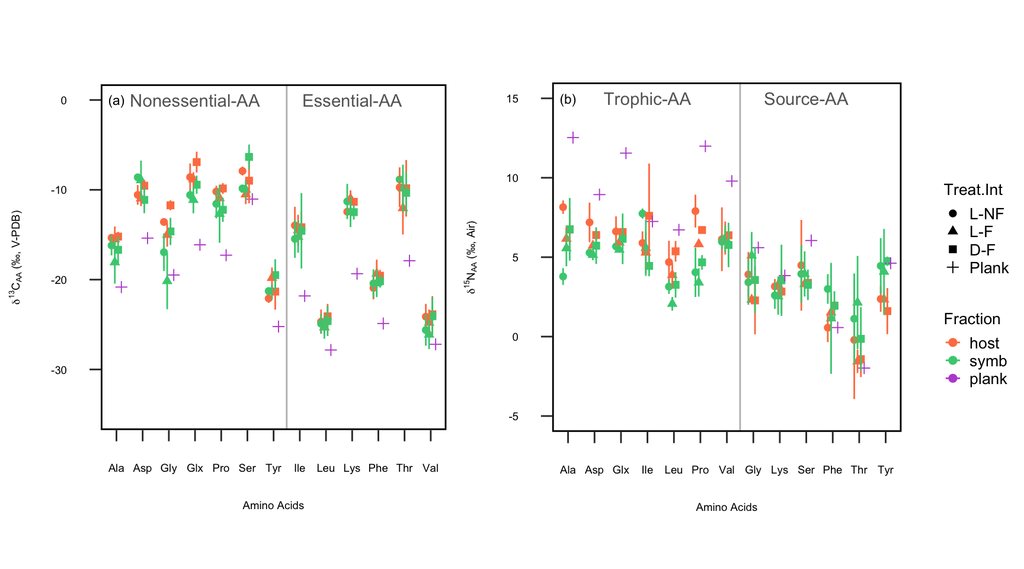

*Figure 3*. (a) Carbon and (b) nitrogen isotope analysis of individual amino acids in coral (host), symbiont algae (symb), and a pooled plankton sample (plank) and in host and symbiont tissues in response to nutrition treatment: Dark-Fed (D-F), Light-Fed (L-F), and Light-Not Fed (L-NF). Values are mean ± SD (n=2), except for the plankton sample (n=1).

```r
leg1 <- get_legend(
  # create some space to the left of the legend
  d13C.CSIA_frac.trt + theme(legend.box.margin = margin(0, 0, 0, 12)))

AA.frac.trt<- plot_grid(d13C.CSIA_frac.trt + ggtitle("")+
                            theme(legend.position = "none",
                                  axis.text.x=element_text(size=7),
                                  axis.text.y=element_text(size=7),
                                  axis.title.x=element_text(size=7),
                                  axis.title.y=element_text(size=7)) +
                            annotate(geom="text", size=3, label="(a)", x=1, y=0, color="black"),
                       d15N.CSIA_frac.trt + ggtitle("") +
                            theme(legend.position = "none",
                                  axis.text.x=element_text(size=7),
                                  axis.text.y=element_text(size=7),
                                  axis.title.x=element_text(size=7),
                                  axis.title.y=element_text(size=7)) +
                       annotate(geom="text", size=3, label="(b)", x=1, y=15, color="black"),
                       ncol=2,nrow=1)
plot_grid(AA.frac.trt, leg1, rel_widths = c(8, 1)) # legend  1/8 size as first obj.
```